# Challenge

1. Biểu diễn qua biểu đồ để tìm sự khác biệt về khả năng sống sót của hành khách trên chuyến tàu titanic theo: Giới tính, độ tuổi.
2. Thống kê mô tả về các biến có thể đo lường được liên quan đến hành khách trên tàu titanic.

```python
import pandas as pd
import numpy as np
import seaborn as sns
import matplotlib.pyplot as plt
from scipy import stats
```

```python
train= pd.read_csv('https://storage.googleapis.com/kaggle-competitions-data/kaggle/3136/train.csv?GoogleAccessId=web-data@kaggle-161607.iam.gserviceaccount.com&Expires=1554284816&Signature=UjtrOvuNiCGoRCcwmEdubY3AOxmE6zpaxBFQBEn78gf50FNc7LfoszFyPCHd%2B4%2FHPy1NapOoPophK5rj6gkkSxrfouUg7nRJ798GioWNOSXLxdq3XzossFL63wJShyzeSu2hYIo%2BS9r1dSXpn%2B9hJ14pe%2Ba%2BGwEjzjhBrYDLVIqmAkzhWKk2Og0byJ%2FQ9Qeek7XIiLQ0Tp%2Fa3S9ihrjKcqnXUc%2FXg5mEtxgjRMXv3awZe1jrNeUJFoP1yZzmudXYpWhI2uPKGllPHjMpBB4JWgZ6draIDY9CYwXI0n7sYiSP%2Be1IYLc%2B4zvg24DFHOoSpOYNZ0bDCuUu72qBsBMvtg%3D%3D')
train.head()
```

|  | PassengerId | Survived | Pclass | Name | Sex | Age | SibSp | Parch | Ticket | Fare | Cabin | Embarked |
| --- | --- | --- | --- | --- | --- | --- | --- | --- | --- | --- | --- | --- |
| 0 | 1 | 0 | 3 | Braund, Mr. Owen Harris | male | 22.0 | 1 | 0 | A/5 21171 | 7.2500 | NaN | S |
| 1 | 2 | 1 | 1 | Cumings, Mrs. John Bradley (Florence Briggs Th... | female | 38.0 | 1 | 0 | PC 17599 | 71.2833 | C85 | C |
| 2 | 3 | 1 | 3 | Heikkinen, Miss. Laina | female | 26.0 | 0 | 0 | STON/O2. 3101282 | 7.9250 | NaN | S |
| 3 | 4 | 1 | 1 | Futrelle, Mrs. Jacques Heath (Lily May Peel) | female | 35.0 | 1 | 0 | 113803 | 53.1000 | C123 | S |
| 4 | 5 | 0 | 3 | Allen, Mr. William Henry | male | 35.0 | 0 | 0 | 373450 | 8.0500 | NaN | S |

```python
train.columns
```

```
Index(['PassengerId', 'Survived', 'Pclass', 'Name', 'Sex', 'Age', 'SibSp',
       'Parch', 'Ticket', 'Fare', 'Cabin', 'Embarked'],
      dtype='object')
```

```python
train.dtypes
```

```
PassengerId      int64
Survived         int64
Pclass           int64
Name            object
Sex             object
Age            float64
SibSp            int64
Parch            int64
Ticket          object
Fare           float64
Cabin           object
Embarked        object
dtype: object
```

```python
sns.set(color_codes=True)
```

**Lọc dữ liệu cần dùng**

Chúng ta chỉ cần dữ liệu tuổi, giới tính và kế quả sống chết đầu tiên

```python
table1= train.loc[:, ['Survived','Sex','Age']].copy()
table1.isna().sum()
```

```
Survived      0
Sex           0
Age         177
dtype: int64
```

```python
table1.dropna(inplace=True)
table1.head()
```

|  | Survived | Sex | Age |
| --- | --- | --- | --- |
| 0 | 0 | male | 22.0 |
| 1 | 1 | female | 38.0 |
| 2 | 1 | female | 26.0 |
| 3 | 1 | female | 35.0 |
| 4 | 0 | male | 35.0 |

# Yêu cầu đầu tiên của đề bài

Biểu diễn qua biểu đồ để tìm sự khác biệt về khả năng sống sót của hành khách trên chuyến tàu titanic theo: Giới tính, độ tuổi.

## Phân bố tuổi theo giới tính

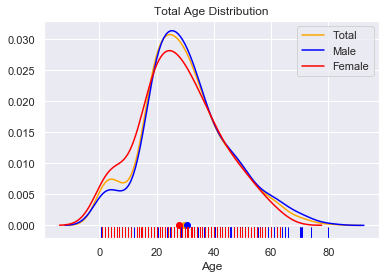

```python
plt.title('Total Age Distribution')
sns.distplot(table1['Age'], color='orange', hist=False, rug=True, label='Total')
plt.scatter(table1['Age'].mean(), 0, color='orange')

sns.distplot(table1.loc[(table1['Sex']=='male'), ['Age']].copy(), color= 'blue', hist=False, rug=True, label= 'Male')
sns.distplot(table1.loc[(table1['Sex']=='female'), ['Age']].copy(), color= 'red', hist=False, rug=True, label= 'Female')
plt.scatter(table1.loc[(table1['Sex']=='male'),['Age']].mean(), 0, color='blue')
plt.scatter(table1.loc[(table1['Sex']=='female'),['Age']].mean(), 0, color='red')
```

Đồ thị nhìn tổng thể (chấm trung bình) lệch về phía những người trẻ tuổi. Như vậy trên tàu trước khi xảy ra tai nạn **có rất nhiều người trẻ tuổi và trẻ em.**

## Phân bố khả năng sống sót qua độ tuổi

Ta lọc ra 2 bảng dữ liệu những người sống và chết, sau đó phân tích phân bố tuổi tác giới tính.

```python
live= table1.loc[(table1['Survived']==0), ['Sex', 'Age']].copy()
die= table1.loc[(table1['Survived']==1), ['Sex', 'Age']].copy()
```

**Phân tích khả năng sống sót khi chỉ xét về độ tuổi**

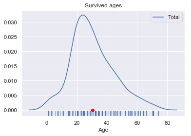

```python
plt.title('Survived ages')
sns.distplot(live['Age'], hist=False, rug=True,label= 'Total')
plt.scatter(live['Age'].mean(), 0, color='red')
```

Chúng ta cũng kì vọng một tỉ lệ tương tự ở trẻ em và người già. Trong trường hợp đó khả năng sống sót sẽ độc lập với yếu tố tuổi tác của hành khách.

Chúng ta thấy điều đó ở lứa tuổi >40. Tuy nhiên lại thấy sự **giảm nhẹ ở trẻ em (<10 tuổi): chỉ khoảng 5% sống sót so với tỉ lệ trước đó (~7.5%).**

**Phân tích khả năn sống sót dựa trên độ tuổi và giới tính**

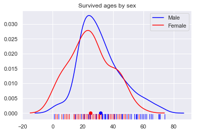

```python
plt.title('Survived ages by sex')
sns.distplot(live.loc[(live['Sex']=='male'), ['Age']].copy(), color= 'blue', hist=False, rug=True, label= 'Male')
sns.distplot(live.loc[(live['Sex']=='female'), ['Age']].copy(), color= 'red', hist=False, rug=True, label= 'Female')
plt.scatter(live.loc[(live['Sex']=='male')].mean(), 0, color='blue')
plt.scatter(live.loc[(live['Sex']=='female')].mean(), 0, color='red')
```

Ta thấy **khả năng sống sót ở nữ trẻ tuổi là khá cao**, đặc biệt khi phân bố sống sót của trẻ em nữ (<10 tuổi) cao gấp khoảng 2 lần (~15%) tỉ lệ tổng số trẻ em có trên tàu (~7.5%). Tỉ lệ sống sót của các quý bà **từ 40-45 cũng cao hơn hẳn**, và **giảm mạnh sau 50 tuổi**. Mặc dù vậy nữ giới trẻ tuổi khoảng **25 tuổi vẫn có tỉ lệ sống sót cao nhất trong nhóm nữ.**

## Kiểm tra lại với tỉ lệ tử vong

**Tỉ lệ tử vong theo độ tuổi**

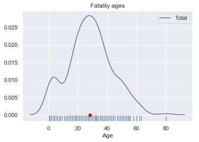

```python
plt.title('Fatality ages')
sns.distplot(die['Age'], hist=False, rug=True, label= 'Total')
plt.scatter(die['Age'].mean(), 0, color='red')
```

**Tỉ lệ tử vong theo giới tính và độ tuổi**

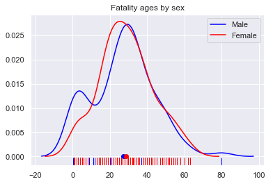

```python
plt.title('Fatality ages by sex')
sns.distplot(die.loc[(die['Sex']=='male'), ['Age']].copy(), color= 'blue', hist=False, rug=True, label= 'Male')
sns.distplot(die.loc[(die['Sex']=='female'), ['Age']].copy(), color= 'red', hist=False, rug=True, label= 'Female')
plt.scatter(die.loc[(die['Sex']=='male')].mean(), 0, color='blue')
plt.scatter(die.loc[(die['Sex']=='female')].mean(), 0, color='red')
```

Chính vì vậy, trong khi nhóm trẻ tuổi ở cả nam và nữ đều có tỉ lệ tử vong cao nhất, tỉ lệ sống sót cũng cao nhất, thể hiện khả năng sống/chết là trung bình ở những người trẻ bất kể nam hay nữ.

**Chúng ta thấy rõ hơn hiện tượng này ở đồ thị dưới đây**

```python
diey= die.loc[(die['Sex']=='male'), ['Age']].reset_index().drop(['index'], axis=1).copy()
diey.rename(columns={'Age':'Male Age Dead'}, inplace=True)

livey= live.loc[(live['Sex']=='male'), ['Age']].reset_index().drop(['index'], axis=1).copy()
livey.rename(columns={'Age':'Male Age Survived'}, inplace=True)

Male_survival= pd.concat([livey, diey], axis=1, sort=False)
Male_survival
```

|  | Male Age Survived | Male Age Dead |
| --- | --- | --- |
| 0 | 22.0 | 34.00 |
| 1 | 35.0 | 28.00 |
| 2 | 54.0 | 32.00 |
| 3 | 2.0 | 0.83 |
| 4 | 20.0 | 29.00 |
| 5 | 39.0 | 23.00 |
| 6 | 2.0 | 12.00 |
| 7 | 35.0 | 24.00 |
| 8 | 19.0 | 27.00 |
| 9 | 40.0 | 9.00 |
| 10 | 66.0 | 1.00 |
| 11 | 28.0 | 45.00 |
| 12 | 42.0 | 3.00 |
| 13 | 21.0 | 18.00 |
| 14 | 7.0 | 26.00 |
| 15 | 21.0 | 40.00 |
| 16 | 65.0 | 16.00 |
| 17 | 28.5 | 38.00 |
| 18 | 11.0 | 19.00 |
| 19 | 22.0 | 37.00 |
| 20 | 45.0 | 3.00 |
| 21 | 4.0 | 25.00 |
| 22 | 19.0 | 25.00 |
| 23 | 26.0 | 19.00 |
| 24 | 32.0 | 30.00 |
| 25 | 21.0 | 42.00 |
| 26 | 26.0 | 0.92 |
| 27 | 25.0 | 45.00 |
| 28 | 22.0 | 2.00 |
| 29 | 28.0 | 3.00 |
| ... | ... | ... |
| 330 | 43.0 | NaN |
| 331 | 10.0 | NaN |
| 332 | 38.0 | NaN |
| 333 | 2.0 | NaN |
| 334 | 23.0 | NaN |
| 335 | 18.0 | NaN |
| 336 | 21.0 | NaN |
| 337 | 20.0 | NaN |
| 338 | 16.0 | NaN |
| 339 | 34.5 | NaN |
| 340 | 17.0 | NaN |
| 341 | 42.0 | NaN |
| 342 | 35.0 | NaN |
| 343 | 28.0 | NaN |
| 344 | 4.0 | NaN |
| 345 | 74.0 | NaN |
| 346 | 41.0 | NaN |
| 347 | 21.0 | NaN |
| 348 | 24.0 | NaN |
| 349 | 31.0 | NaN |
| 350 | 26.0 | NaN |
| 351 | 33.0 | NaN |
| 352 | 47.0 | NaN |
| 353 | 20.0 | NaN |
| 354 | 19.0 | NaN |
| 355 | 33.0 | NaN |
| 356 | 28.0 | NaN |
| 357 | 25.0 | NaN |
| 358 | 27.0 | NaN |
| 359 | 32.0 | NaN |

360 rows × 2 columns

**So sánh đồ thị sống sót và tử vong ở nam giới**

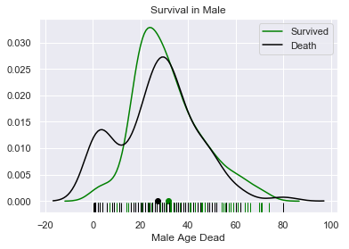

```python
plt.title('Survival in Male')
sns.distplot(Male_survival['Male Age Survived'], color= 'green', hist=False, rug=True, label= 'Survived')
sns.distplot(Male_survival['Male Age Dead'], color= 'black', hist=False, rug=True, label= 'Death')
plt.scatter(Male_survival['Male Age Survived'].mean(), 0, color='green')
plt.scatter(Male_survival['Male Age Dead'].mean(), 0, color='black')
```

```python
diex= die.loc[(die['Sex']=='female'), ['Age']].reset_index().drop(['index'], axis=1).copy()
diex.rename(columns={'Age':'Female Age Dead'}, inplace=True)

livex= live.loc[(live['Sex']=='female'), ['Age']].reset_index().drop(['index'], axis=1).copy()
livex.rename(columns={'Age':'Female Age Survived'}, inplace=True)

Female_survival= pd.concat([livex, diex], axis=1, sort=False)
Female_survival
```

|  | Female Age Survived | Female Age Dead |
| --- | --- | --- |
| 0 | 14.0 | 38.0 |
| 1 | 31.0 | 26.0 |
| 2 | 8.0 | 35.0 |
| 3 | 18.0 | 27.0 |
| 4 | 40.0 | 14.0 |
| 5 | 27.0 | 4.0 |
| 6 | 18.0 | 58.0 |
| 7 | 16.0 | 55.0 |
| 8 | 28.0 | 15.0 |
| 9 | 14.5 | 38.0 |
| 10 | 20.0 | 14.0 |
| 11 | 17.0 | 3.0 |
| 12 | 2.0 | 19.0 |
| 13 | 47.0 | 49.0 |
| 14 | 9.0 | 29.0 |
| 15 | 45.0 | 21.0 |
| 16 | 50.0 | 5.0 |
| 17 | 24.0 | 38.0 |
| 18 | 2.0 | 29.0 |
| 19 | 25.0 | 17.0 |
| 20 | 29.0 | 30.0 |
| 21 | 41.0 | 17.0 |
| 22 | 45.0 | 33.0 |
| 23 | 24.0 | 23.0 |
| 24 | 2.0 | 34.0 |
| 25 | 26.0 | 21.0 |
| 26 | 38.0 | 32.5 |
| 27 | 45.0 | 29.0 |
| 28 | 3.0 | 19.0 |
| 29 | 31.0 | 22.0 |
| ... | ... | ... |
| 167 | NaN | 51.0 |
| 168 | NaN | 54.0 |
| 169 | NaN | 5.0 |
| 170 | NaN | 43.0 |
| 171 | NaN | 13.0 |
| 172 | NaN | 17.0 |
| 173 | NaN | 18.0 |
| 174 | NaN | 49.0 |
| 175 | NaN | 31.0 |
| 176 | NaN | 31.0 |
| 177 | NaN | 33.0 |
| 178 | NaN | 52.0 |
| 179 | NaN | 27.0 |
| 180 | NaN | 62.0 |
| 181 | NaN | 15.0 |
| 182 | NaN | 39.0 |
| 183 | NaN | 30.0 |
| 184 | NaN | 16.0 |
| 185 | NaN | 18.0 |
| 186 | NaN | 45.0 |
| 187 | NaN | 24.0 |
| 188 | NaN | 48.0 |
| 189 | NaN | 42.0 |
| 190 | NaN | 27.0 |
| 191 | NaN | 47.0 |
| 192 | NaN | 28.0 |
| 193 | NaN | 15.0 |
| 194 | NaN | 56.0 |
| 195 | NaN | 25.0 |
| 196 | NaN | 19.0 |

197 rows × 2 columns

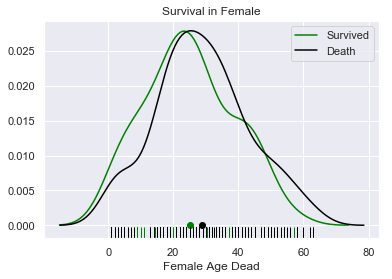

```python
plt.title('Survival in Female')
sns.distplot(Female_survival['Female Age Survived'], color= 'green', hist=False, rug=True, label= 'Survived' )
sns.distplot(Female_survival['Female Age Dead'], color= 'black', hist=False, rug=True, label= 'Death')
plt.scatter(Female_survival['Female Age Survived'].mean(), 0, color='green')
plt.scatter(Female_survival['Female Age Dead'].mean(), 0, color='black')
```

## Pclass- Embarked

Ở phân tích này ta sẽ xem liệu tầng lớp địa vị (Pclass) và địa điểm (Embarked) xuất phát của một người có cho anh ta lợi thế về khả năng sống sót so với những người khác hay không! Liệu thời điểm gặp nạn có phải người giàu hơn thì được cứu hay không?

```python
table2= train.loc[:, ['Survived','Pclass','Embarked']].copy()
table2.isna().sum()
```

```
Survived    0
Pclass      0
Embarked    2
dtype: int64
```

```python
table2.dropna(inplace=True)
table2.head()
```

|  | Survived | Pclass | Embarked |
| --- | --- | --- | --- |
| 0 | 0 | 3 | S |
| 1 | 1 | 1 | C |
| 2 | 1 | 3 | S |
| 3 | 1 | 1 | S |
| 4 | 0 | 3 | S |

Lọc, đếm thông tin từ bảng table2

```python
#counting total

first= len(table2.loc[(table2['Pclass']==1)])
second= len(table2.loc[(table2['Pclass']==2)])
third= len(table2.loc[(table2['Pclass']==3)])

c= len(table2.loc[(table2['Embarked']=='C')])
s= len(table2.loc[(table2['Embarked']=='S')])
q= len(table2.loc[(table2['Embarked']=='Q')])


#Survival count

#live
firstl= len(livedemo.loc[(livedemo['Pclass']==1)])
secondl= len(livedemo.loc[(livedemo['Pclass']==2)])
thirdl= len(livedemo.loc[(livedemo['Pclass']==3)])

cl= len(livedemo.loc[(livedemo['Embarked']=='C')])
sl= len(livedemo.loc[(livedemo['Embarked']=='S')])
ql= len(livedemo.loc[(livedemo['Embarked']=='Q')])
```

[output not shown]

[output not shown]

**Phân bố số lượng hành khách dựa trên Pclass**

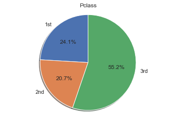

```python
labels1 = '1st', '2nd', '3rd'
count1 = [first, second, third]



sns.set_palette("deep")

f, (ax1) = plt.subplots(1, 1, sharey=True)
ax1.pie(count1, labels=labels1, autopct='%1.1f%%',
        shadow=True, startangle=90)
ax1.axis('equal')

ax1.set_title('Pclass')
```

Ta thấy 1st class và 2nd bị giới hạn hơn 3rd class. Từ đây ta có **2 nhóm thiểu số là 1st và 2nd class.**

**Xác suất sống sót của các hành khách dựa trên Pclass**

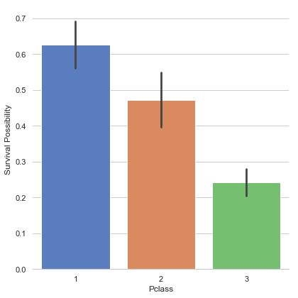

```python
sns.set(style="whitegrid")
sns.set_palette("deep")
g = sns.catplot(x="Pclass", y='Survived', hue=None, data=table2,
                height=6, kind="bar", palette="muted")
g.despine(left=True)
g.set_ylabels("Survival Possibility")
```

Đến đây ta thấy xét về xác suất thì người giàu có khả năng sống sót cao hơn. Tuy nhiên nhóm nhà giàu 1st và 2nd class lại là nhóm thiểu số. Điều đó nghĩa là khả năng sống sót cao hơn của người giàu không nhất thiết phải là kết quả của một sự phân biệt giàu nghèo nào trong thời điểm xảy ra tai nạn mà có thể là do khi được lên thuyền cứu hộ nhóm thiểu số nhanh chóng đạt được tỉ lệ cao hơn với cùng một đơn vị người mà nhóm đa số cứu được. Nói cách khác có thể có sự bình đẳng về cơ hội sống ở đây, và hiển nhiên là nhóm thiểu số sẽ nhanh được rút hết xuống thuyền cứu hộ hơn.

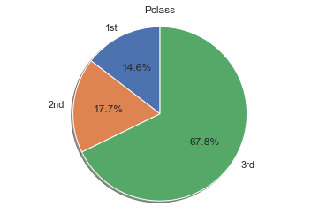

```python
labels1 = '1st', '2nd', '3rd'
count1 = [firstl, secondl, thirdl]



sns.set_palette("deep")

f, (ax1) = plt.subplots(1, 1, sharey=True)
ax1.pie(count1, labels=labels1, autopct='%1.1f%%',
        shadow=True, startangle=90)
ax1.axis('equal')

ax1.set_title('Pclass')
```

**Phân bổ số hành khách dựa trên địa điểm xuất phát**

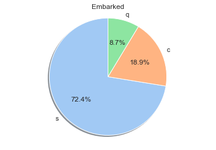

```python
sns.set_palette("pastel")
labels2 = 's', 'c','q'
count2 = [s, c , q]

f, ( ax2) = plt.subplots(1, 1, sharey=True)

ax2.pie(count2, labels=labels2, autopct='%1.1f%%',
        shadow=True, startangle=90)
ax2.axis('equal')
ax2.set_title('Embarked')

plt.show()
```

Ở đây ta có nhóm thiểu số nhất 'q', tiếp đến là 'c' và nhóm đa số 's'.

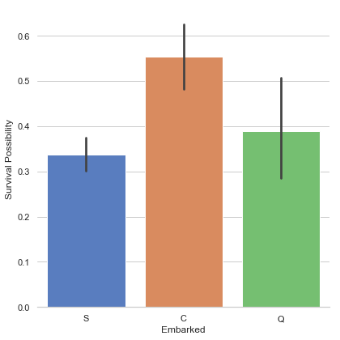

```python
sns.set(style="whitegrid")
sns.set_palette("pastel")
g = sns.catplot(x="Embarked", y='Survived', hue=None, data=table2,
                height=6, kind="bar", palette="muted")
g.despine(left=True)
g.set_ylabels("Survival Possibility")
```

Kiểm tra lại địa điểm C thuộc Pháp, còn địa điểm S và Q thuộc Anh. Như vậy khả năng cao nhóm C đại diện cho những người Pháp/và dân các nước khác từ lục địa đến Pháp để lên tàu, và S Q đại diện những người Anh. **Như vậy về bản chất biểu đồ thể hiện xác xuất sống sót giữa người Anh và người ngoại quốc.**

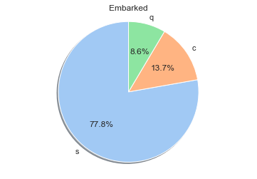

```python
sns.set_palette("pastel")
labels2 = 's', 'c','q'
count2 = [sl, cl , ql]

f, ( ax2) = plt.subplots(1, 1, sharey=True)

ax2.pie(count2, labels=labels2, autopct='%1.1f%%',
        shadow=True, startangle=90)
ax2.axis('equal')
ax2.set_title('Embarked')

plt.show()
```

**Tổng hợp lại về Pclass và Embarked**

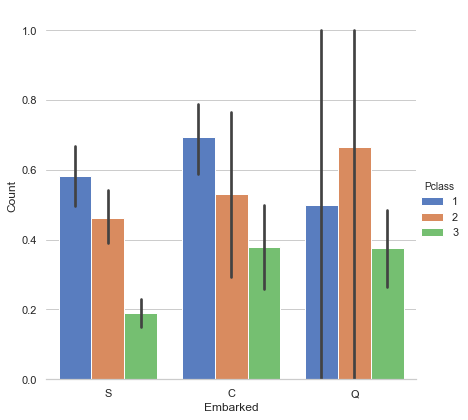

```python
sns.set(style="whitegrid")
sns.set_palette("pastel")
g = sns.catplot(x="Embarked", y='Survived', hue='Pclass', data=table2,
                height=6, kind="bar", palette="muted")
g.despine(left=True)
g.set_ylabels("Count")
```

**Như vậy khả năng sống sót của những người ngoại quốc (không phải Anh), và thuộc nhóm thiểu số (giàu có) là cao nhất.**

# sibsp-parch

Ở phân tích này ta sẽ xem khả năng sống sót của nhưng người đi cùng gia đình (parch) và người thân (sibsp) ra sao.

```python
table3= train.loc[:, ['Survived','SibSp','Parch']].copy()
table3.isna().sum()
```

```
Survived    0
SibSp       0
Parch       0
dtype: int64
```

```python
table3['SibSp'].unique()
```

```
array([1, 0, 3, 4, 2, 5, 8], dtype=int64)
```

```python
table3['Parch'].unique()
```

```
array([0, 1, 2, 5, 3, 4, 6], dtype=int64)
```

**Thử vẽ biểu đồ các hành khách đi một mình và theo nhóm**

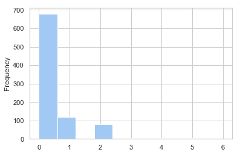

```python
table3['Parch'].plot(kind= 'hist' )
```

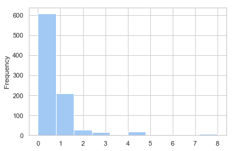

```python
table3['SibSp'].plot(kind= 'hist')
```

Thay vì phân thành nhiều nhóm trong trường hợp này ta sẽ chỉ phân thành 2 nhóm đi một mình (Single) và đi theo nhóm (Group). Việc đi cùng gia đình (Parch) hay người thân (SibSp) sẽ được gộp vào làm một. Trạng thái bạn đồng hành (Company Status), sẽ là cơ sở để phân tích liệu đi theo nhóm (Company Status=1) có đem lại xác xuất sống xót cao hơn hay không.

```python
table3['Company Status']= table3['SibSp'] + table3['Parch']
table3.drop(['SibSp', 'Parch'], axis=1, inplace= True)
table3.head()
```

|  | Survived | Company Status |
| --- | --- | --- |
| 0 | 0 | 1 |
| 1 | 1 | 1 |
| 2 | 1 | 0 |
| 3 | 1 | 1 |
| 4 | 0 | 0 |

Đếm số hành khách đi một mình và theo nhóm

```python
table3fix = table3.replace (table3.loc[(table3['Company Status']>1), ['Company Status']],value= 1)
ps0=len(table3fix.loc[(table3fix['Company Status']==0)])
ps= len(table3fix.loc[(table3fix['Company Status']==1)])
```

**Biểu đồ phân bổ hành khách theo trạng thái có bạn đồng hành**

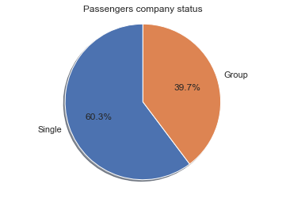

```python
labels = 'Single', 'Group'
count = [ps0, ps]

sns.set_palette("deep")

f, (ax1) = plt.subplots(1, 1, sharey=True)
ax1.pie(count, labels=labels, autopct='%1.1f%%',
        shadow=True, startangle=90)
ax1.axis('equal')

ax1.set_title('Passengers company status')
```

**Tỉ lệ sống sót giữa việc đi theo nhóm hay đi một mình**

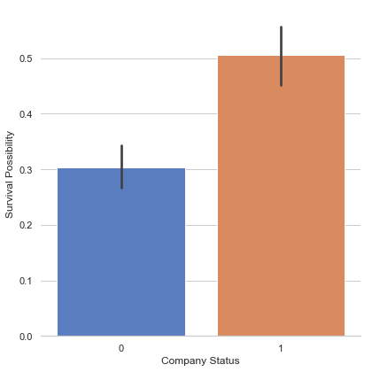

```python
sns.set(style="whitegrid")
sns.set_palette("pastel")
g = sns.catplot(x="Company Status", y='Survived', hue=None, data=table3fix,
                height=6, kind="bar", palette="muted")
g.despine(left=True)
g.set_ylabels("Survival Possibility")
```

Như vậy các **hành khách đi theo nhóm (gia đình, người thân) sẽ có cơ hội sống sót cao hơn các hành khách đi một mình.**

```
                                                        # The End
```